# Maladaptive plastic responses of flowering time to geothermal heating (Cerastium 2)

Analyses with logger data

Alicia Valdés

# Plot with all logger data, one line per logger id

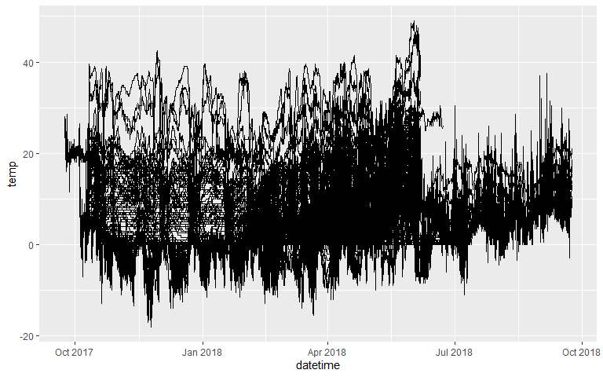

# Q1: Are instantaneous measures of soil temperature representative for the conditions during the entire spring/growing season?

Correlations logger temperature - instant temperature

## May

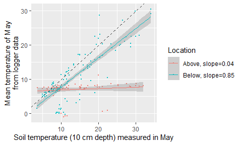

[output not shown]

Correlation mean temperature of may from logger data and soil temperature measured in may with thermometer:

```
[1] 0.6446784
```

Correlation mean temperature of may from logger data (only belowground loggers) and soil temperature measured in may with thermometer:

```
[1] 0.8614051
```

Correlation mean temperature of may from logger data (only aboveground loggers) and soil temperature measured in may with thermometer:

```
[1] 0.1263677
```

## Whole period

For each logger_nr, get mean temperature during the whole period available and compare with temp_term (which was measured with a thermometer at 10 cm depth on May 2017):

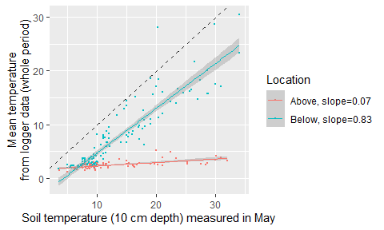

```
MODEL INFO:
Observations: 78
 mean_logger
Type: OLS linear regression

MODEL FIT:
F(1,76) = 54.027, p = 0.000
R² = 0.416
Adj. R² = 0.408

Standard errors: OLS
--------------------------------------------------
                     Est.    S.E.   t val.       p
----------------- ------- ------- -------- -------
(Intercept)         1.633   0.138   11.819   0.000
temp_term           0.066   0.009    7.350   0.000
--------------------------------------------------
MODEL INFO:
Observations: 141
Dependent Variable: mean_logger
Type: OLS linear regression

MODEL FIT:
F(1,139) = 686.807, p = 0.000
R² = 0.832
Adj. R² = 0.830

Standard errors: OLS
---------------------------------------------------
                      Est.    S.E.   t val.       p
----------------- -------- ------- -------- -------
(Intercept)         -3.547   0.465   -7.623   0.000
temp_term            0.832   0.032   26.207   0.000
---------------------------------------------------
```

Correlation mean temperature from logger data and soil temperature measured in may with thermometer:

```
[1] 0.6700633
```

Correlation mean temperature from logger data (only belowground loggers) and soil temperature measured in may with thermometer:

```
[1] 0.9119648
```

Correlation mean temperature from logger data (only aboveground loggers) and soil temperature measured in may with thermometer:

```
[1] 0.6445959
```

The correlation values seem to indicate that the temperature measured with a thermometer represents quite well longer-term conditions

# Q2: Do differences between soil and air temperatures change with soil temperature?

For the plants with aboveground loggers, we have air temperature and soil temperature measured at the same exact location (air temperature measured by the aboveground logger and soil temperature measured with the thermometer). We use these plants to test for correlations between air and soil temperature.

## All temperature values

### Logger data for the whole period:

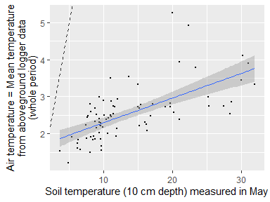

```
MODEL INFO:
Observations: 78
Dependent Variable: mean_logger
Type: OLS linear regression

MODEL FIT:
F(1,76) = 54.027, p = 0.000
R² = 0.416
Adj. R² = 0.408

Standard errors: OLS
--------------------------------------------------
                     Est.    S.E.   t val.       p
----------------- ------- ------- -------- -------
(Intercept)         1.633   0.138   11.819   0.000
temp_term           0.066   0.009    7.350   0.000
--------------------------------------------------
Linear hypothesis test

Hypothesis:
temp_term = 1

Model 1: restricted model
Model 2: mean_logger ~ temp_term

  Res.Df    RSS Df Sum of Sq     F    Pr(>F)
1     77 3339.5
2     76   23.6  1    3315.9 10658 < 2.2e-16 ***
---
Signif. codes:  0 ‘***’ 0.001 ‘**’ 0.01 ‘*’ 0.05 ‘.’ 0.1 ‘ ’ 1
```

The slope is significantly different from 1: differences between soil and air temperature change with soil temperature, being larger at higher soil temperatures.

### Logger data for May:

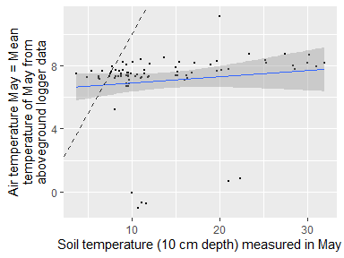

[output not shown]

When looking only at air temperature in May, the slope is also significantly different from 1. But it is not significantly different from zero! So there is no relationship between soil and air temperature.

### Logger data for April-May-June:

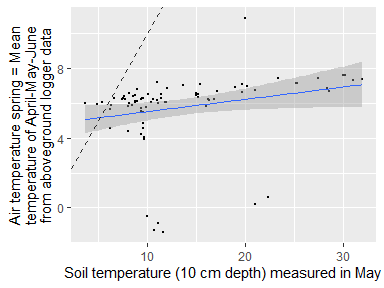

```
MODEL INFO:
Observations: 78
Dependent Variable: meanspring_logger
Type: OLS linear regression

MODEL FIT:
F(1,76) = 4.642, p = 0.034
R² = 0.058
Adj. R² = 0.045

Standard errors: OLS
--------------------------------------------------
                     Est.    S.E.   t val.       p
----------------- ------- ------- -------- -------
(Intercept)         4.805   0.501    9.592   0.000
temp_term           0.071   0.033    2.154   0.034
--------------------------------------------------
Linear hypothesis test

Hypothesis:
temp_term = 1

Model 1: restricted model
Model 2: meanspring_logger ~ temp_term

  Res.Df    RSS Df Sum of Sq      F    Pr(>F)
1     77 3597.1
2     76  310.6  1    3286.5 804.06 < 2.2e-16 ***
---
Signif. codes:  0 ‘***’ 0.001 ‘**’ 0.01 ‘*’ 0.05 ‘.’ 0.1 ‘ ’ 1
```

When looking at air temperature in the period April-May-June, the slope is also significantly different from 1: differences between soil and air temperature change with soil temperature, being larger at higher soil temperatures.

## Daily temperature values

Repeat what was done above using only daily values of air temperature (after 8 am and before or equal to 8 pm).

### Logger data for the whole period:

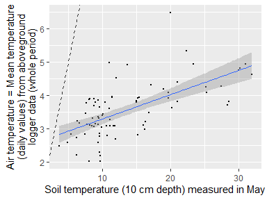

```
MODEL INFO:
Observations: 78
Dependent Variable: mean_logger
Type: OLS linear regression

MODEL FIT:
F(1,76) = 50.038, p = 0.000
R² = 0.397
Adj. R² = 0.389

Standard errors: OLS
--------------------------------------------------
                     Est.    S.E.   t val.       p
----------------- ------- ------- -------- -------
(Intercept)         2.566   0.157   16.343   0.000
temp_term           0.073   0.010    7.074   0.000
--------------------------------------------------
Linear hypothesis test

Hypothesis:
temp_term = 1

Model 1: restricted model
Model 2: mean_logger ~ temp_term

  Res.Df    RSS Df Sum of Sq    F    Pr(>F)
1     77 3302.6
2     76   30.5  1    3272.1 8152 < 2.2e-16 ***
---
Signif. codes:  0 ‘***’ 0.001 ‘**’ 0.01 ‘*’ 0.05 ‘.’ 0.1 ‘ ’ 1
```

### Logger data for May:

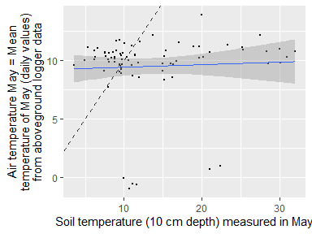

[output not shown]

### Logger data for April-May-June:

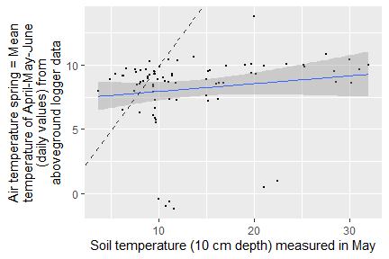

```
MODEL INFO:
Observations: 78
Dependent Variable: meanspring_logger
Type: OLS linear regression

MODEL FIT:
F(1,76) = 1.799, p = 0.184
R² = 0.023
Adj. R² = 0.010

Standard errors: OLS
--------------------------------------------------
                     Est.    S.E.   t val.       p
----------------- ------- ------- -------- -------
(Intercept)         7.340   0.689   10.651   0.000
temp_term           0.060   0.045    1.341   0.184
--------------------------------------------------
Linear hypothesis test

Hypothesis:
temp_term = 1

Model 1: restricted model
Model 2: meanspring_logger ~ temp_term

  Res.Df    RSS Df Sum of Sq      F    Pr(>F)
1     77 3946.4
2     76  587.9  1    3358.5 434.13 < 2.2e-16 ***
---
Signif. codes:  0 ‘***’ 0.001 ‘**’ 0.01 ‘*’ 0.05 ‘.’ 0.1 ‘ ’ 1
```

## Positive temperature values

### Logger data for the whole period:

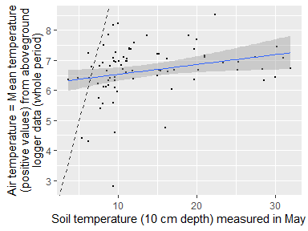

[output not shown]

### Logger data for May:

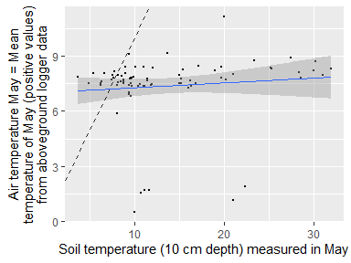

```
MODEL INFO:
Observations: 78
Dependent Variable: meanmay_logger
Type: OLS linear regression

MODEL FIT:
F(1,76) = 0.773, p = 0.382
R² = 0.010
Adj. R² = -0.003

Standard errors: OLS
--------------------------------------------------
                     Est.    S.E.   t val.       p
----------------- ------- ------- -------- -------
(Intercept)         7.011   0.457   15.342   0.000
temp_term           0.026   0.030    0.879   0.382
--------------------------------------------------
Linear hypothesis test

Hypothesis:
temp_term = 1

Model 1: restricted model
Model 2: meanmay_logger ~ temp_term

  Res.Df    RSS Df Sum of Sq      F    Pr(>F)
1     77 3866.0
2     76  258.5  1    3607.5 1060.6 < 2.2e-16 ***
---
Signif. codes:  0 ‘***’ 0.001 ‘**’ 0.01 ‘*’ 0.05 ‘.’ 0.1 ‘ ’ 1
```

### Logger data for April-May-June:

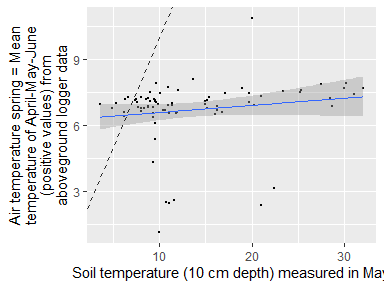

```
MODEL INFO:
Observations: 78
Dependent Variable: meanspring_logger
Type: OLS linear regression

MODEL FIT:
F(1,76) = 1.944, p = 0.167
R² = 0.025
Adj. R² = 0.012

Standard errors: OLS
--------------------------------------------------
                     Est.    S.E.   t val.       p
----------------- ------- ------- -------- -------
(Intercept)         6.277   0.357   17.573   0.000
temp_term           0.033   0.023    1.394   0.167
--------------------------------------------------
Linear hypothesis test

Hypothesis:
temp_term = 1

Model 1: restricted model
Model 2: meanspring_logger ~ temp_term

  Res.Df    RSS Df Sum of Sq      F    Pr(>F)
1     77 3718.9
2     76  157.9  1    3560.9 1713.6 < 2.2e-16 ***
---
Signif. codes:  0 ‘***’ 0.001 ‘**’ 0.01 ‘*’ 0.05 ‘.’ 0.1 ‘ ’ 1
```

# Q3: Do correlations between soil and air temperature vary with soil temperature?

Or: How useful soil temperature is as a cue for air temperature, i.e., as a cue for spring advancement?

## Option 1 (probably not used): use plots to calculate correlations between soil and air logger temperatures

### Correlations soil-air temperature over the period April-May-June

For each date and plot, calculate mean, max and min of air and soil temperature (from, respectively, above and belowground loggers). Then, calculate the correlation coefficient for air and soil temperatures over the period April-May-June. Finally, regress these correlation coefficients on mean soil temperature for each plot for the same period.

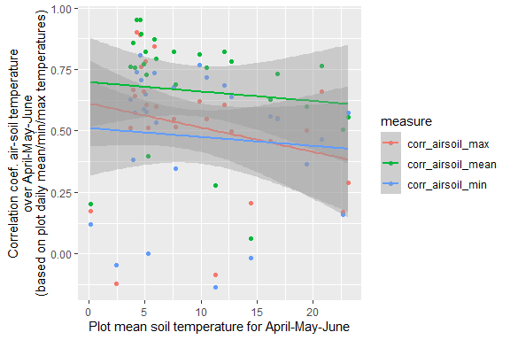

Several plots with negative correlations!

Linear models testing the effect of soil temperature on correlations between soil and air temperature:

| measure | term | estimate | std.error | statistic | p.value |
| --- | --- | --- | --- | --- | --- |
| corr_airsoil_max | (Intercept) | 0.6119703 | 0.0862149 | 7.0981923 | 0.0000002 |
| corr_airsoil_max | meansoiltemp | -0.0098613 | 0.0075418 | -1.3075468 | 0.2024719 |
| corr_airsoil_mean | (Intercept) | 0.6977323 | 0.0892365 | 7.8189095 | 0.0000000 |
| corr_airsoil_mean | meansoiltemp | -0.0038386 | 0.0078061 | -0.4917393 | 0.6270297 |
| corr_airsoil_min | (Intercept) | 0.5107733 | 0.0943600 | 5.4130303 | 0.0000113 |
| corr_airsoil_min | meansoiltemp | -0.0036281 | 0.0082543 | -0.4395358 | 0.6639051 |

Non-significant in all cases.

### Correlations soil-air temperature for May only

For each date and plot, calculate mean, max and min of air and soil temperature (from, respectively, above and belowground loggers). Then, calculate the correlation coefficient for air and soil temperatures over the month of May. Finally, regress these correlation coefficients on mean soil temperature for each plot for the same period.

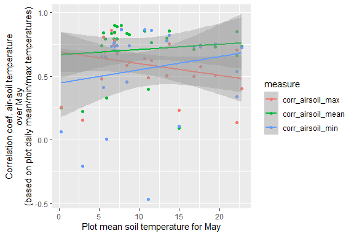

Several plots with negative correlations!

Linear models testing the effect of soil temperature on correlations between soil and air temperature:

| measure | term | estimate | std.error | statistic | p.value |
| --- | --- | --- | --- | --- | --- |
| corr_airsoil_max | (Intercept) | 0.6919312 | 0.0788774 | 8.7722341 | 0.0000000 |
| corr_airsoil_max | meansoiltemp | -0.0092418 | 0.0065041 | -1.4209164 | 0.1672242 |
| corr_airsoil_mean | (Intercept) | 0.6680271 | 0.0884666 | 7.5511777 | 0.0000001 |
| corr_airsoil_mean | meansoiltemp | 0.0041009 | 0.0072948 | 0.5621674 | 0.5788169 |
| corr_airsoil_min | (Intercept) | 0.4456083 | 0.1342556 | 3.3191049 | 0.0026774 |
| corr_airsoil_min | meansoiltemp | 0.0104284 | 0.0110705 | 0.9419963 | 0.3548655 |

Non-significant in all cases.

## Option 2: try to pair loggers

### Paired logger data

Plot with all paired logger data, one line per logger id

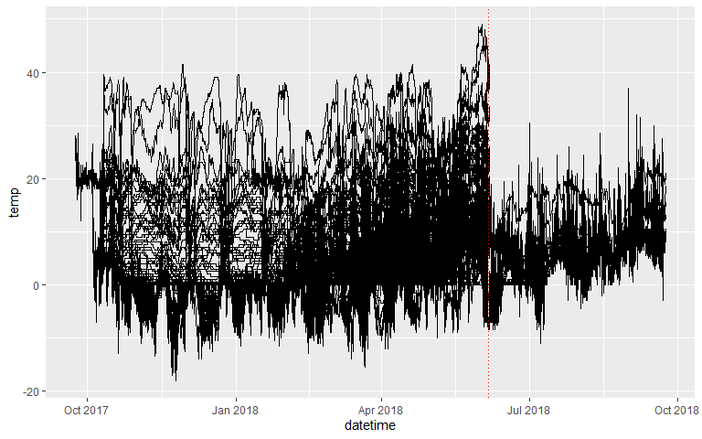

| logger_nr | pair | last_date |
| --- | --- | --- |
| 103 | 1 | 2018-06-06 12:11:00 |
| 105 | 1 | 2018-06-06 13:44:00 |
| 101 | 2 | 2018-06-06 11:34:00 |
| 104 | 2 | 2018-06-06 13:16:00 |
| 108 | 3 | 2018-06-06 12:52:00 |
| 113 | 3 | 2018-06-06 11:02:00 |
| 111 | 4 | 2018-06-06 12:59:00 |
| 115 | 4 | 2018-06-06 12:04:00 |
| 117 | 5 | 2018-06-06 10:43:00 |
| 122 | 5 | 2018-06-06 13:36:00 |

[output cut: 136 more lines]

Most loggers (131 out of 145) end up on June 6th. So probably using May is OK.

### Analyses using all pairs

#### Correlations soil-air temperature over the period April-May-June

##### Based on 24-h values

For each date and logger pair, calculate mean, max and min of air and soil temperature (from, respectively, the above and belowground logger). Then, calculate the correlation coefficient for air and soil temperatures over the period April-May-June. Finally, regress these correlation coefficients on mean soil temperature (from the belowground logger) **for the same period (April-May-June)**.

Using only data till June 5th, included (as most loggers stop on June 6th).

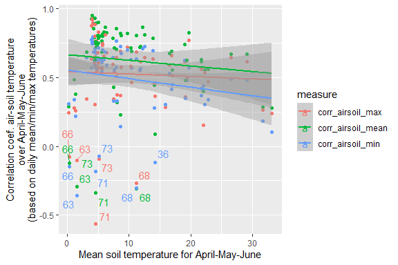

###### Look at the pairs with negative correlations in detail

Pairs with negative correlations: 36 (only for min), 63, 66, 68, 71, 73.

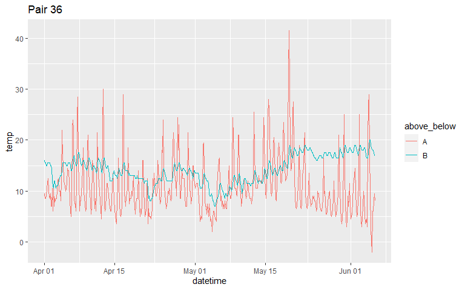

I cannot see anything worrying in the graph. As the negative correlation is only for the min temperature, and it is also not very negative, maybe there is nothing strange here?

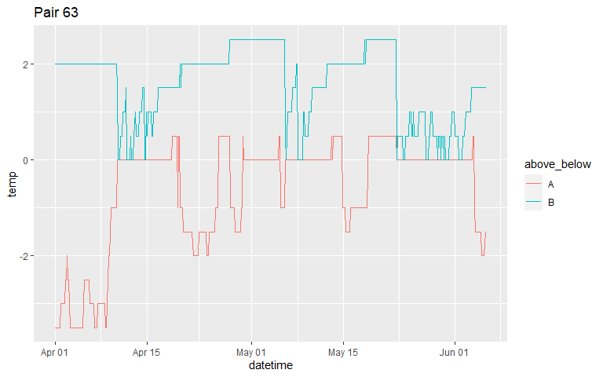

Here, both loggers have constant values of temperature for several periods of time.

The next graph shows all loggers in the same plot as pair 63:

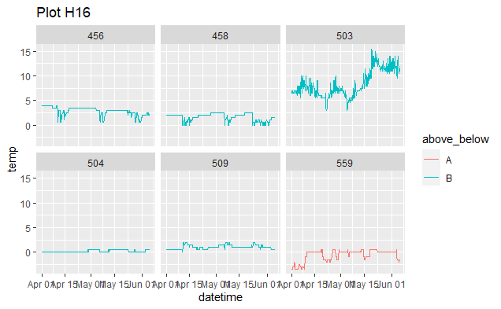

All but one have similar patterns, with constant values for some time periods.

Here is the spatial distribution of the loggers in the plot:

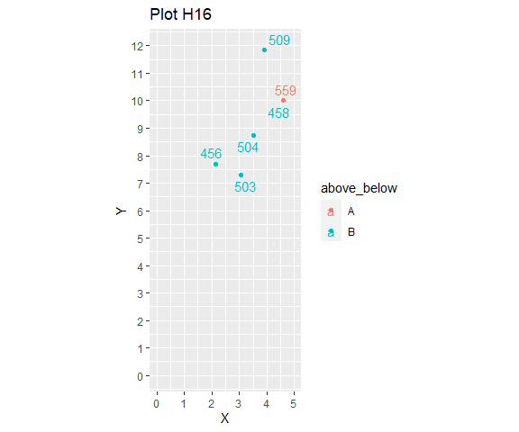

Maybe part of the plot was covered by snow, causing this low variation, and logger 503 was not?

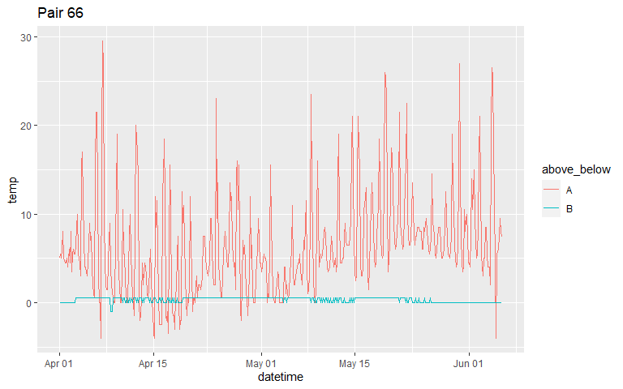

The next graph shows all loggers in the same plot as pair 66:

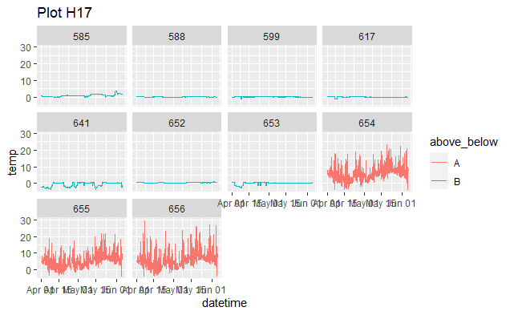

All the belowground loggers show similar patters, with very low variation. However, the aboveground loggers look fine, even if they are located at the same plant that a belowground logger (see locations in the graph below). So this is probably not due to effects of snow? Or could it be that the aboveground loggers are out of the snow but the belowground ones are covered by snow?

And the locations in the plot:

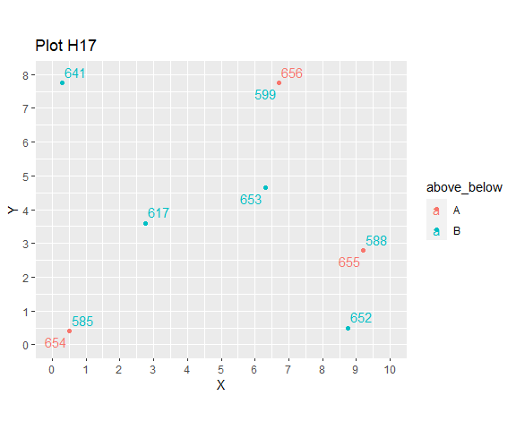

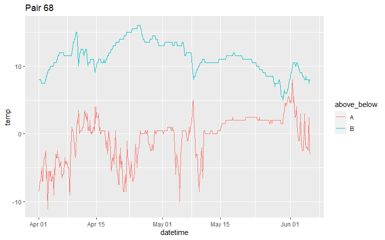

The next graph shows all loggers in the same plot as pair 68:

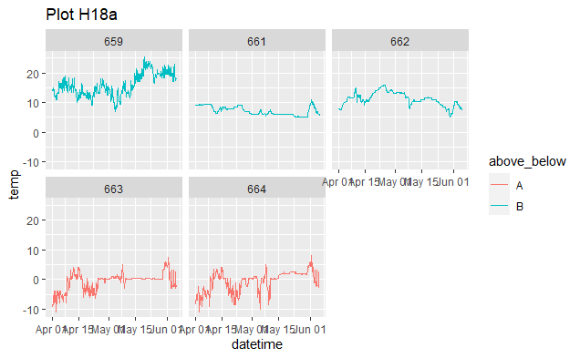

And the locations in the plot:

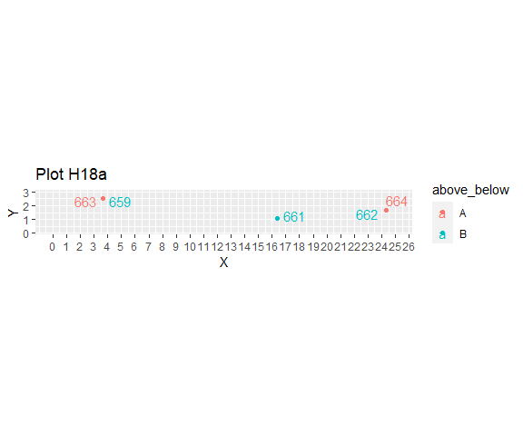

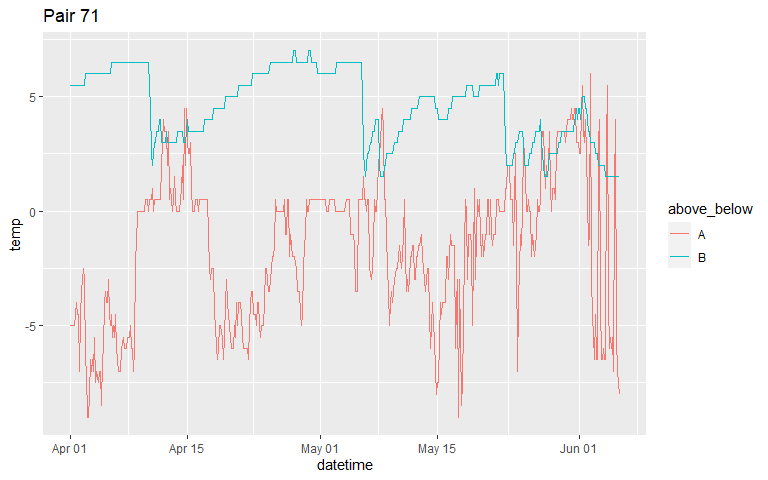

One can really see the negative correlation in this pair! The “peaks” for the aboveground logger coincide with the “valleys” for the belowground one.

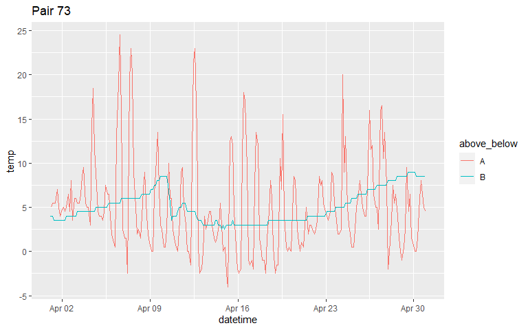

The next graph shows all loggers in the same plot as pair 71 and 73:

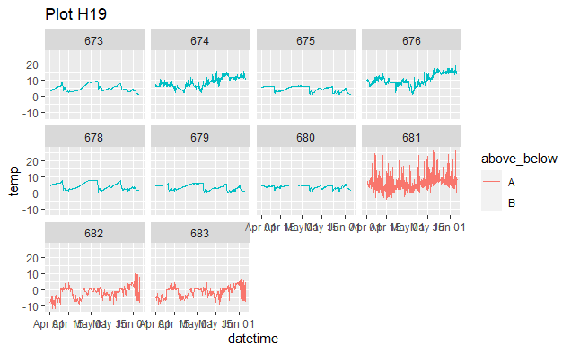

And the locations in the plot:

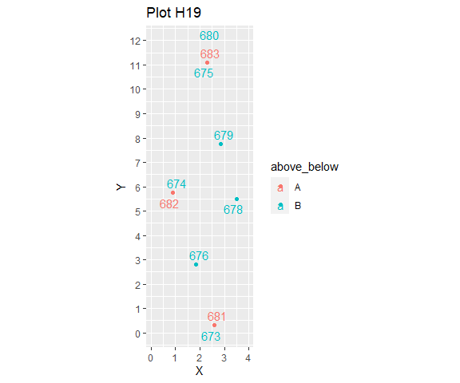

Linear models testing the effect of soil temperature on correlations between soil and air temperature:

| measure | term | estimate | std.error | statistic | p.value |
| --- | --- | --- | --- | --- | --- |
| corr_airsoil_max | (Intercept) | 0.5414445 | 0.0532531 | 10.1673811 | 0.0000000 |
| corr_airsoil_max | meansoiltemp | -0.0017789 | 0.0041961 | -0.4239331 | 0.6728962 |
| corr_airsoil_mean | (Intercept) | 0.6639691 | 0.0590038 | 11.2529902 | 0.0000000 |
| corr_airsoil_mean | meansoiltemp | -0.0040923 | 0.0046493 | -0.8801977 | 0.3817219 |
| corr_airsoil_min | (Intercept) | 0.5528005 | 0.0510155 | 10.8359418 | 0.0000000 |
| corr_airsoil_min | meansoiltemp | -0.0062181 | 0.0040198 | -1.5468504 | 0.1263454 |

Non-significant in all cases.

Linear models testing the effect of soil temperature on correlations between soil and air temperature, removing pairs with negative correlations (5-6 pairs):

| measure | term | estimate | std.error | statistic | p.value |
| --- | --- | --- | --- | --- | --- |
| corr_airsoil_max | (Intercept) | 0.6532763 | 0.0357085 | 18.294692 | 0.0000000 |
| corr_airsoil_max | meansoiltemp | -0.0071265 | 0.0027362 | -2.604566 | 0.0113544 |
| corr_airsoil_mean | (Intercept) | 0.7963235 | 0.0374644 | 21.255451 | 0.0000000 |
| corr_airsoil_mean | meansoiltemp | -0.0105272 | 0.0028707 | -3.667091 | 0.0004913 |
| corr_airsoil_min | (Intercept) | 0.6686414 | 0.0301222 | 22.197651 | 0.0000000 |
| corr_airsoil_min | meansoiltemp | -0.0111786 | 0.0023113 | -4.836430 | 0.0000085 |

All significant!

And the graph:

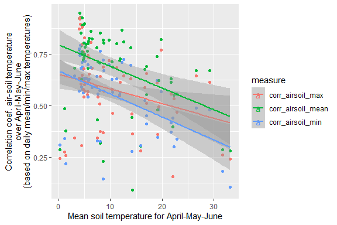